# data-analysis-replication

# *Discussion and Reflection*

A dataset that could have made my life easier, was if the author had loaded a dataset with the complete set of species and RMRs, instead of me having to manually import them. The analysis replications were incredibly difficult as the paper does not mention how any of the calculations were done besides listing what R packages were used for the calculations.

## Statistical Replications/Reanalysis

# References

Citing the dataset: Legendre, Lucas J.; Guénard, Guillaume; Botha-Brink, Jennifer; Cubo, Jorge (2016). Data from: Palaeohistological evidence for ancestral high metabolic rate in archosaurs [Dataset]. Dryad. https://doi.org/10.5061/dryad.2853k

Citing the paper: Lucas J. Legendre, Guillaume Guénard, Jennifer Botha-Brink, Jorge Cubo, Palaeohistological Evidence for Ancestral High Metabolic Rate in Archosaurs, Systematic Biology, Volume 65, Issue 6, November 2016, Pages 989–996, https://doi.org/10.1093/sysbio/syw033

## Load anole tree

anole.tree <- read.tree(“http://www.phytools.org/eqg2015/data/anole.tre”)

## Load anole trait data, extract snout-vent-length (svl) as named vector

svl <- fulldata %>% mutate(svl = set_names(svl, Species)) %>% pull(svl)

ssvl <- tibia %>% mutate(svl=set_names(svl, Species)) %>% pull(svl)

head(anole.tree)

obj<-contMap(phylocomplete, svl,plot=FALSE)

head(completetree)

plot(obj,lwd=7,xlim=c(-0.2,3.6)) errorbar.contMap(obj)

fit <- fastAnc(phylocomplete,svl,vars=TRUE,CI=TRUE)

## load data from Garland et al. (1992)

tipnames

## estimate ancestral body sizes

Ancestral<-fastAnc(phylocomplete,tipnames,vars = FALSE, CI=TRUE) print(fit.BM,printlen=10)

phylocomplete[ is.na(phylocomplete) ] <- 0 phylocomplete$tip.label <- as.numeric(do.call(paste0, phylocomplete))

head(completetree)

if(any(is.na(phylocomplete$tip.label))){ stop("NA values found in phylocomplete$tip.label. Please ensure all tip labels are non- NA.”)}

drop.tip(phylocomplete, phylocomplete$tip.label, trim.internal = TRUE)

tib_label<- get_tip_labels(phylocomplete)

tipnames<-TipLabels(phylocomplete, single=TRUE)

tip_labelss <- phylocomplete$tip.label[!is.na(phylocomplete$tip.label)]

ancestral_states <- fastAnc(phylocomplete, tip.label, vars = FALSE, CI = FALSE)

head(phylocomplete)

```
 ancestral_states <- fastAnc(completetree, completetree$tip.label,names(RMR), vars = FALSE, CI = FALSE)
```

ancestral_states <- fastAnc(phylocomplete, phylocomplete$tip.label, vars = FALSE, CI = FALSE)

class(phylocomplete$tip.label)

setdiff(phylocomplete$tip.label) setdiff(completetree$tip.label,names(RMR)) #fastAnc(phylocomplete,phylocomplete$edge.length, vars=FALSE, CI=FALSE)

#edge_lengths <- setNames(phylocomplete$edge.length, phylocomplete$tip.label)

ancestral_states <- fastAnc(phylocomplete, RMR, vars = FALSE, CI = FALSE)

#edge_lengths <- edge_lengths[match(phylocomplete$tip.label, names(edge_lengths))]

#ancestral_states <- fastAnc(phylocomplete, edge_lengths, vars = FALSE, CI = FALSE)

#head(ancestral_states)

#colnames(ancestral_states) ## extract character of interest #fastAn <-log(setNames(phylocomplete$edge.legth, # rownames(phylocomplete)))

#class(phylocomplete$edge.length) ## estimate ancestral body sizes #fit.BM<-fastAnc(Maintree,ln.bodyMass,CI=TRUE) #print(fit.BM,printlen=10)

#fastAnc(phylocomplete, x_ordered, vars = FALSE, CI = FALSE)

#str(phylocomplete) #x_ordered <- phylocomplete$tip.label[match(phylocomplete, phylocomplete$tip.label)]

#ancestralstates <- fastAnc(complete, complete$tip.label)

# Extra

This section contains extra replications I have done for this project although they did not show up as figures on the paper.

I once again read the NEXUS file, converted to phylo object, plotten tree using ggtree by adding tip labels and applyinga tree like theme.,

[figure not shown]

```r
t <- "/Users/jessicavaldes/Desktop/R2024/FINAL.PROJECT/TreefemurMeta.nex"


femurtree <- read.nexus(file = "/Users/jessicavaldes/Desktop/R2024/FINAL.PROJECT/TreefemurMeta.nex")

phylofemurtree <- as.phylo(femurtree)

femurtreeplot <-(ggtree(phylofemurtree) +
  geom_tiplab() +
  theme_tree()  )

plot(femurtreeplot)
```

[figure not shown]

```r
t <- "/Users/jessicavaldes/Desktop/R2024/FINAL.PROJECT/TreefemurMeta.nex"


femurtree <- read.nexus(file = "/Users/jessicavaldes/Desktop/R2024/FINAL.PROJECT/TreefemurMeta.nex")

phylofemurtree <- as.phylo(femurtree)


ggtree(phylofemurtree) +
  geom_tiplab() +
  theme_tree()
```

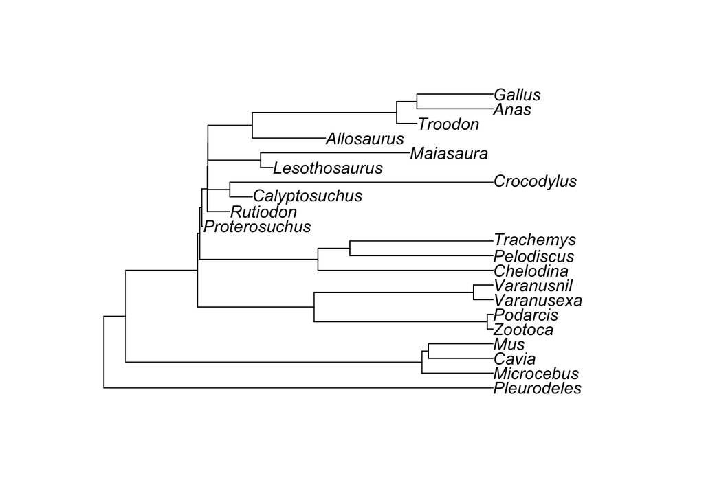

```r
plot(femurtree)
```

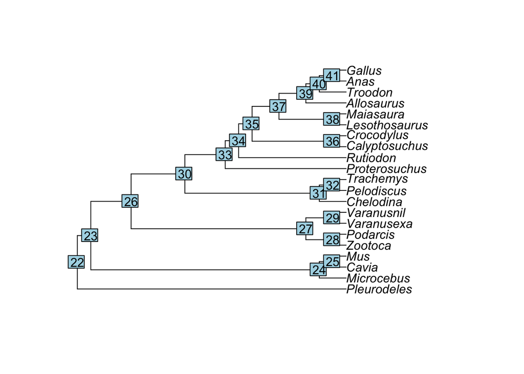

```r
plot(femurtree, use.edge.length=FALSE)
nodelabels()
```

```r
femurtree<- rotate.multi(femurtree, 22)
femurtree<- rotate.multi(femurtree, 23)
femurtree<- rotate.multi(femurtree, 24)
femurtree<- rotate.multi(femurtree, 25)
femurtree<- rotate.multi(femurtree, 26)
femurtree<- rotate.multi(femurtree, 27)
femurtree<- rotate.multi(femurtree, 28)
femurtree<- rotate.multi(femurtree, 29)
femurtree<- rotate.multi(femurtree, 30)
femurtree<- rotate.multi(femurtree, 31)
femurtree<- rotate.multi(femurtree, 32)
femurtree<- rotate.multi(femurtree, 33)
femurtree<- rotate.multi(femurtree, 34)
femurtree<- rotate.multi(femurtree, 35)
femurtree<- rotate.multi(femurtree, 36)
femurtree<- rotate.multi(femurtree, 37)
femurtree<- rotate.multi(femurtree, 38)
femurtree<- rotate.multi(femurtree, 39)
femurtree<- rotate.multi(femurtree, 40)
femurtree<- rotate.multi(femurtree, 41)
```

Humerus tree shown here.

[figure not shown]

```r
humerustree <- read.nexus(file = "/Users/jessicavaldes/Desktop/R2024/FINAL.PROJECT/TreehumerusMeta.nex")

phylohumerustree <- as.phylo(humerustree)


humerustreeplot <- (ggtree(phylohumerustree) +
  geom_tiplab() +
  theme_tree()   )

plot(humerustreeplot)
```

Tibia Tree plotted below

[figure not shown]

```r
tibiatree <- read.nexus(file = "/Users/jessicavaldes/Desktop/R2024/FINAL.PROJECT/TreetibiaMeta.nex")

phylotibiatree <- as.phylo(tibiatree)


tibiatreeplot <-(ggtree(phylotibiatree) +
  geom_tiplab() +
  theme_tree())

plot(tibiatreeplot)
```

#```{r}

#in order to extract PEM first I

# Extract eigenvectors from the tree

head(grloc)

sporder <- match(attr(grloc$x,"vlabel")[grloc$x$vertex$species],phylocomplete[,“species”])

#then I build the PME, here is a list of variables

aux <- c(“Vasc_density”,“Cell_density”,“Cell_size”,“Cell_shape”)

1+1

[output not shown]

#```{r}

# Extract eigenvectors from the tree

femur1 <- femur[,c(2,4:6)]<-log(femur[,c(2,4:6)]); femur[,3]<-log1p(femur[,3])

#here I combine all transformed data FEMURDATA <- cbind(Species, RMR, logVD, logROD, logOA, logOS)

colnames(editedfemur)[1] <- “RMR”

grloc <- getGraphLocations(Ftree,editedfemur[is.na(editedfemur[,“RMR”]),“Species”])

sporder <- match(attr(grloc$x,"vlabel")[grloc$x$vertex$Species],editedfemur[,“Species”])

[output not shown]

head(complete) grloc <- getGraphLocations(phylofemurtree,data[is.na(data[,“RMR”]),“Species”])

phylofemurtree<- as.phylo(femurtree)

head(femurtree) str(complete)

grloc <- getGraphLocations(LucasTree,FEMURDATA[,“RMR”,“Species”])

str(tpall$Nnode)

head(grloc)

sporder <- match(attr(grloc$x,"vlabel")[grloc$x$vertex$Species],FEMURDATA[,“Species”])